# Homework 1

**This homework is due on the deadline posted on edX. Please submit a .pdf file of your output and upload a .zip file containing your .Rmd file. Do NOT include your name or EID in your filenames.**

In this homework you will be working with the `chickwts` dataset built into R. This data set contains weight measurements of chicks fed on different food sources to assess their effectiveness on growth rate.

```r
head(chickwts)
```

|  | weight | feed |
| --- | --- | --- |
| 1 | 179 | horsebean |
| 2 | 160 | horsebean |
| 3 | 136 | horsebean |
| 4 | 227 | horsebean |
| 5 | 217 | horsebean |
| 6 | 168 | horsebean |

**Problem 1:** Use ggplot to make a histogram of the `weight` column. Manually choose appropriate values for `binwidth` and `center`. Explain your choice of values in 2-3 sentences.

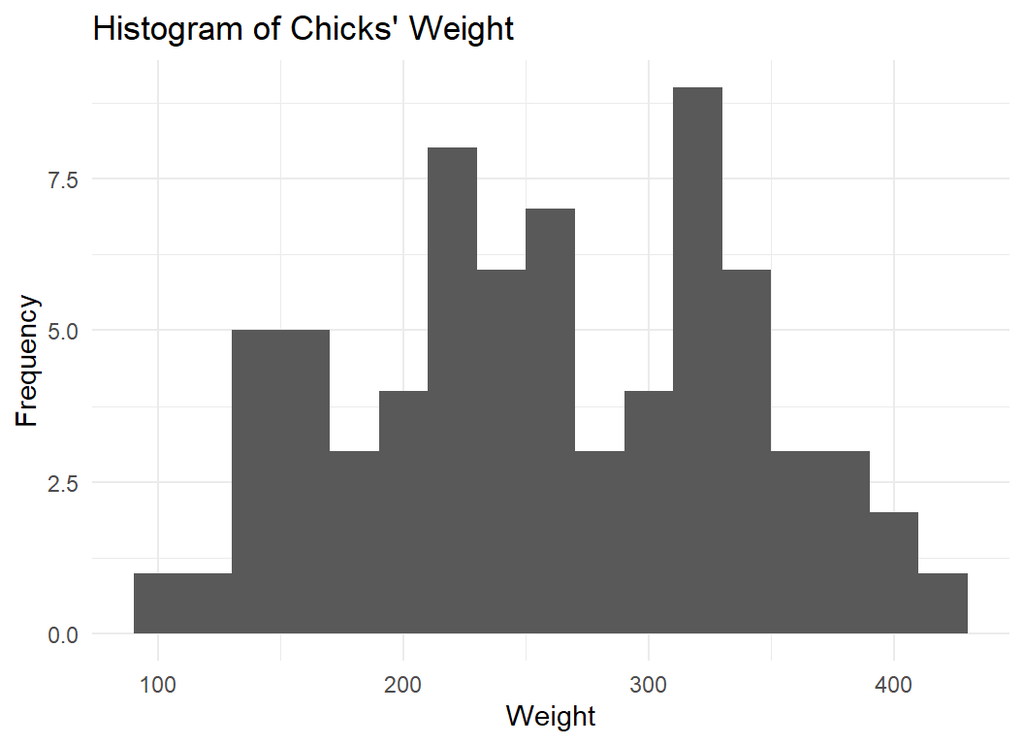

```r
library(ggplot2)

# Create the histogram
ggplot(chickwts, aes(x = weight)) +
  geom_histogram(binwidth = 20, center = 100) +
  labs(title = "Histogram of Chicks' Weight",
       x = "Weight",
       y = "Frequency") +
  theme_minimal()
```

*I chose a binwidth of 20 and a center of 100 based on the distribution of the data. These values provide a clear representation of the weight distribution of the chicks in the Dataset. Adjusting these values may be necessary depending on the specific insights you want to gain from the histogram..*

**Problem 2:** Modify the plot from Problem 1 to show one panel per feed. Hint: Use `facet_wrap()`.

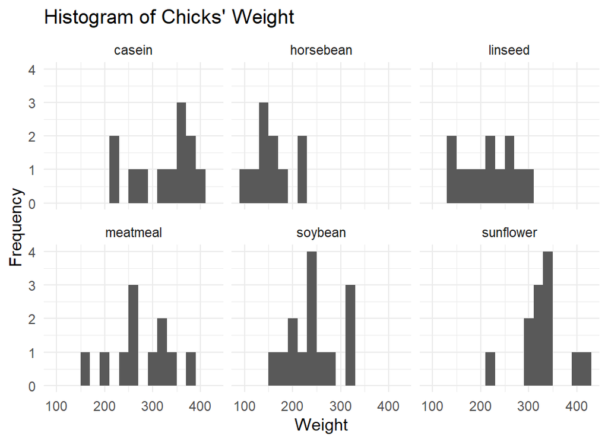

```r
library(ggplot2)

# Create the histogram with facet_wrap
ggplot(chickwts, aes(x = weight)) +
  geom_histogram(binwidth = 20, center = 100) +
  labs(title = "Histogram of Chicks' Weight",
       x = "Weight",
       y = "Frequency") +
  facet_wrap(~ feed, ncol = 3) +
  theme_minimal()
```